# Do’s and don’ts of cluster Analysis - Step by Step Guide

## What is cluster analysis?

**Cluster analysis** **is an unsupervised analytical technique used to identify homogeneous groups within a dataset based on similarities across multiple variables**. **In market research, it is commonly applied to customer segmentation,** allowing researchers to uncover distinct profiles in terms of attitudes, perceptions, or behaviors without relying on predefined labels. By grouping respondents who share similar patterns, cluster analysis helps transform complex survey or behavioral data into actionable segments that can be interpreted from a business perspective. These segments can then be used to inform strategic decisions such as targeting, product positioning, personalization strategies, and the prioritization of customer needs.

## Dataset and Survey Example

The data used in this example are purely synthetic and serve illustrative purposes only.

## Step 1 - Survey design

- Include **all relevant questions** needed to meaningfully differentiate respondents and build segments.
- **Avoid redundant or highly overlapping questions**, as they increase respondent fatigue and add noise to the analytical process.
- **Prefer nominal or metric variables** over ordinal ones whenever possible. Binary answer formats (0–1) are particularly suitable for segmentation, as they create clearer distinctions between respondents.
- While Likert scales are common in market research, their ordinal nature can make the extraction of well-defined clusters more challenging.
- **Design the survey to minimize biases and response styles**. Binary answer options are less prone to acquiescence or extreme responding.
- Binary variables require little to no data pre-processing and can be safely converted into numeric form (0/1). Most statistical methods handle dichotomous variables reliably, without compromising the validity of the analysis.

## Step 2 - Data Collection

- **Ensure a sufficient sample size** relative to the number of segmentation variables. A common rule of thumb is to aim for at least 100 respondents per segmentation variable, in order to achieve stable and interpretable clusters.
- **Apply rigorous participant selection** and quality controls to ensure respondents engage properly with the survey and provide reliable data.
- Use **built-in quality checks** to identify (and eliminate) low-quality responses, such as attention checks in matrix questions, control or consistency questions, time-based filters, and open-ended questions to verify genuine engagement.

## Step 3 - Data Exploration

- Use this stage to **get familiar with the data** and start forming an intuition about which clustering approaches may work best.
- **Check the measurement level of each variable** (nominal, ordinal, metric), as this will influence both distance measures and algorithm choice.
- **Look at univariate distributions to spot skewed variables**, outliers, low-variance items, or unusual response patterns that could affect the results.
- **Explore relationships between variables to identify redundancy**, strong correlations, or overlapping information.
- **Decide whether any data preparation is needed** (e.g. scaling, transformations, dimensionality reduction) before running the clustering algorithms.
- Use insights from this exploration to **understand the strengths and limitations of different segmentation methods** and set realistic expectations for the results.

### Pre-processing

- **Categorical variables**: Two pre-processing procedures are often used for categorical variables. One is merging levels of categorical variables before further analysis, the other one is converting categorical variables to numeric ones, if it makes sense to do so.
- **Ordinal data** can be converted to numeric data if it can be assumed that distances between adjacent scale points on the ordinal scale are approximately equal.
- **Binary answer options are less prone to capturing response styles**, and do not require data pre-processing. Pre-processing inevitably alters the data in some way. Binary variables can always be converted to numeric variables.

### Principal Component Analysis (PCA)

- **Principal Component Analysis (PCA) is a technique that transforms a set of correlated metric variables into a new set of uncorrelated components, ordered by the amount of variance they explain**.
- The first components capture most of the variability in the data, while later components add progressively less information. The relative positions of observations remain unchanged—PCA simply offers a different perspective on the same data space.
- In market segmentation, PCA is often considered as a way to reduce the number of input variables. While this can make the clustering task easier, it also replaces original variables with abstract components, which can reduce interpretability.
- **For this reason, PCA is best used as an exploratory tool rather than as direct input for segmentation.**
- PCA is particularly useful for identifying highly correlated or redundant variables. Variables loading strongly on the same components capture similar information and may be candidates for removal.
- Using PCA insights to eliminate redundant variables reduces dimensionality while preserving the original variables collected in the survey.

The following an example of data exploration using PCA:

PCA Summary (First 3 Components)

Binary variables – no centering or scaling applied

| Component | Eigenvalue | Variance explained | Cumulative variance |
| --- | --- | --- | --- |
| PC1 | 0.660 | 18.1% | 18.1% |
| PC2 | 0.329 | 9.0% | 27.1% |
| PC3 | 0.279 | 7.7% | 34.8% |

**The table summarizes how much variance in the original variables is captured by the first three principal components.** Eigenvalues indicate the absolute amount of variance captured by each principal component, while variance explained expresses this value as a proportion of the total variance, allowing for easier comparison across components.

The fact that the first components explain only a limited share of the variance suggests that there is no single dominant dimension in the data. This means that the original survey items each add useful information and are worth keeping as segmentation variables.

PCA Loadings (PC1–PC3)

Contribution of each item to the principal components

| Variable | PC1 | PC2 | PC3 |
| --- | --- | --- | --- |
| I_trust_this_bank | -0.063 | 0.012 | 0.134 |
| This_bank_is_reliable | -0.109 | 0.393 | -0.117 |
| My_money_feels_safe | -0.095 | 0.146 | -0.046 |
| Transparent_fees_and_costs | -0.277 | 0.223 | -0.210 |
| Good_value_for_money | -0.286 | -0.156 | 0.583 |
| Clear_and_fair_conditions | -0.110 | -0.012 | -0.015 |
| High_quality_customer_service | -0.279 | 0.521 | 0.087 |
| Fast_problem_resolution | -0.284 | -0.010 | 0.129 |
| Staff_is_knowledgeable | -0.140 | 0.051 | 0.004 |
| Easy_to_contact_the_bank | -0.317 | 0.058 | 0.244 |
| Digital_channels_are_easy_to_use | -0.118 | 0.321 | 0.005 |
| Good_mobile_banking_app | -0.049 | 0.240 | -0.299 |
| Innovative_digital_features | -0.353 | -0.267 | -0.398 |
| Wide_range_of_products | -0.241 | -0.213 | -0.076 |
| Products_fit_my_needs | -0.132 | -0.013 | 0.202 |
| Attractive_savings_and_loans | -0.307 | -0.336 | 0.005 |
| Ethical_and_responsible_bank | -0.092 | 0.165 | 0.078 |
| Shares_my_values | -0.269 | -0.183 | -0.056 |
| Positive_brand_reputation | -0.260 | -0.116 | -0.428 |
| I_would_recommend_this_bank | -0.259 | 0.092 | 0.104 |

The PC1 column shows how the first principal component is formed by the original variables. This component mainly reflects a general response tendency, separating respondents who tend to agree with most bank-related statements from those who agree with very few. As a result, **PC1 captures overall response intensity rather than a specific banking dimension, and therefore offers limited direct managerial value.**

**For PC2, the highest loadings are observed on items related to perceived service quality and reliability,** such as high quality customer service, this bank is reliable, and attractive savings and loans.

PC3 is primarily driven by variables associated with brand reputation, and good value for money.

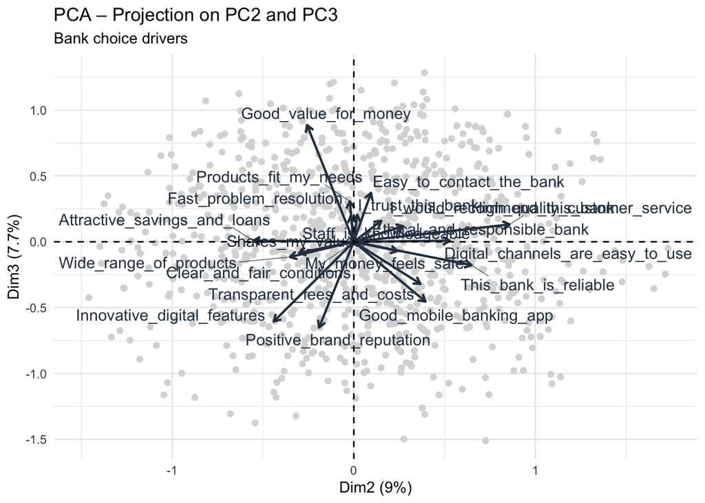

As it can be seen at the graphical representations of components 2 & 3, “Good value for money” is quite a unique motive, while “my money feels safe”and “this bank is reliable”, are part of the same group.

## Step 4 - Extracting algorithms

- **A wide range of clustering algorithms is available,** including distance-based methods, model-based approaches, and techniques with integrated variable selection.
- For this reason, **it is good practice to explore segmentation solutions obtained from multiple algorithms** rather than relying on a single method.
- Different algorithms impose different structures on the data, which can lead to substantially different segment solutions and interpretations.
- **Since there is no single “best” clustering algorithm, comparing alternative solutions is essential to assess robustness, interpretability, and business relevance.**
- **In this guide, we focus on two of the most widely used and intuitive approaches: hierarchical clustering and k-means clustering.**

#### Hierarchical clustering

**Hierarchical clustering** **is an unsupervised segmentation technique that** **groups observations based on their similarity in a step-by-step manner, creating a hierarchy of nested clusters.** Instead of producing a single predefined solution, it builds a tree-like structure (dendrogram) that shows how individual observations progressively merge into larger groups. This makes hierarchical clustering particularly useful in exploratory analysis, as it allows researchers to visually assess different segmentation solutions and understand the underlying structure of the data. In market research, it is often used to gain initial insights into customer heterogeneity, identify natural breakpoints between segments, and support decisions about the appropriate number of clusters before applying other methods.

**The silhouette plot shows how well the data are partitioned for different numbers of clusters**. Higher average silhouette values indicate better-defined and more clearly separated clusters. By comparing solutions, the plot helps identify a reasonable number of clusters before inspecting the dendrogram and profiling the segments.

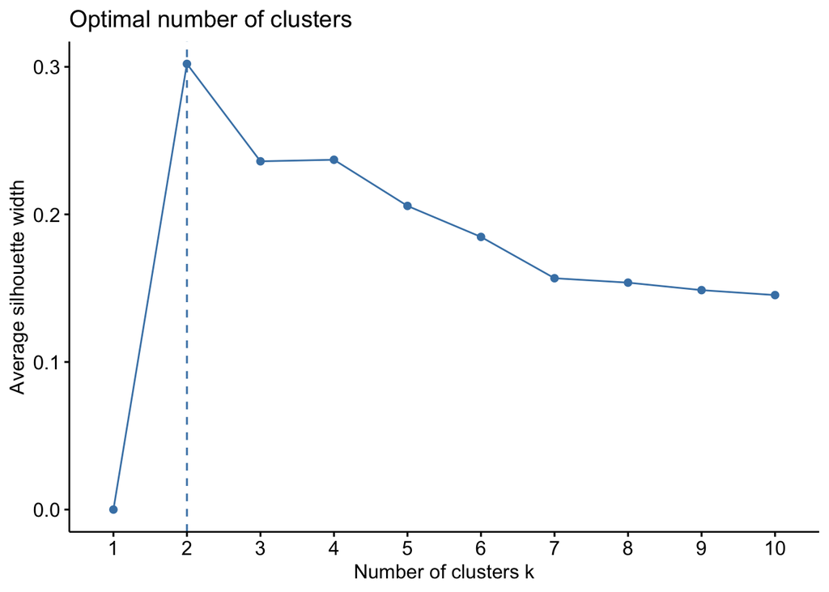

**The plot suggests that the ideal number of clusters is 2**.

**We can then plot the dendogram. A dendrogram is a tree-like diagram that visualizes the hierarchical relationships between observations in a clustering solution.** It shows how individual cases are progressively merged into larger clusters based on their similarity, with the height of each merge reflecting the distance between groups. By inspecting where large jumps in height occur, the dendrogram helps identify natural cut points and validate the chosen number of clusters.

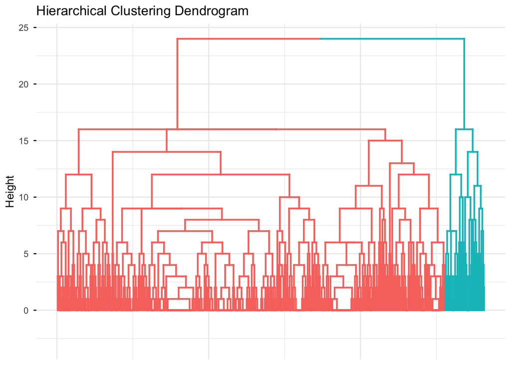

**The barchart shows the average score of each item by cluster, highlighting how segments differ in their underlying profiles:**

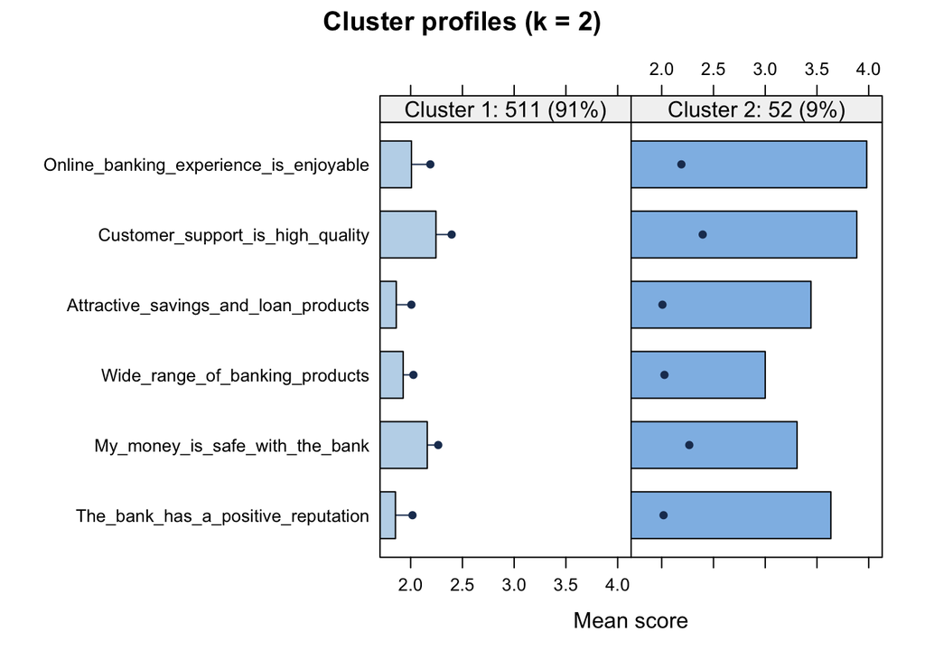

The two-cluster solution mainly separates individuals with consistently low scores across all items from those with consistently high scores. While this split captures a general response tendency, it is overly simplistic and offers limited support for decision-making. For this reason, **it is useful to explore solutions with a higher number of clusters in order to identify more informative and actionable segment structures:**

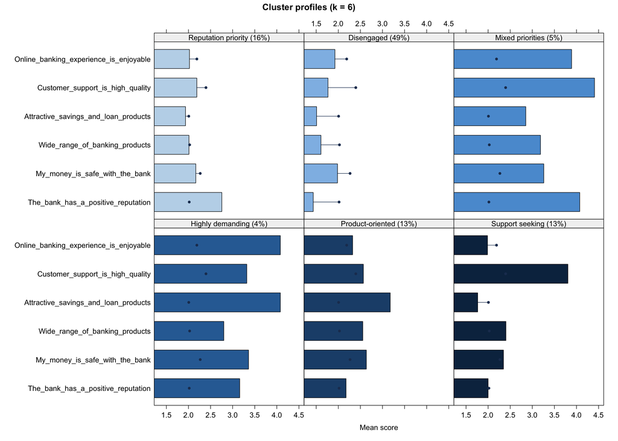

**The six-cluster solution reveals more meaningful differences between segments.** **Cluster 1** (16%) is mainly characterized by high levels of importance to **bank reputation**. **Cluster 2** (49%) shows consistently low scores across all items, indicating **limited engagement** with the bank. **Cluster 3** (5%) places higher value on **customer support**, the online banking experience, and a positive brand reputation. Cluster 4 (4%) is primarily driven by **digital banking** features and attractive savings products, while **Cluster 5** (13%) appears to focus mainly on attractive **savings and loans**. **Cluster 6 (13%)** prioritizes mostly customer **support**. **Compared to the two-cluster solution, this segmentation provides more actionable insights and supports more nuanced decision-making. A thorough analysis would further explore alternative solutions, particularly in the range of three to five clusters, to identify the most informative structure.**

#### K-Means Clustering

**K-means clustering is a simple and intuitive method that groups observations into a fixed number of clusters based on similarity.** It works by repeatedly assigning observations to the nearest cluster center and updating those centers until the solution stabilizes.

In this example we will explore the 6 cluster solution:

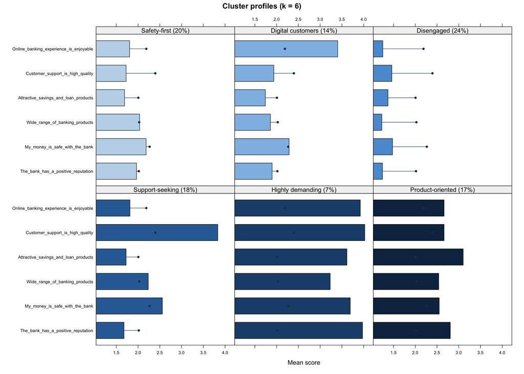

**Comparing the k-means and hierarchical solutions highlights how different algorithms can lead to different, yet valid, segmentations. This underlines the importance of combining quantitative metrics with human judgment when selecting a final solution. Rather than relying on a single method, an ideal segmentation approach would continue exploring alternative algorithms and cluster sizes, selecting the solution that best balances interpretability, business relevance, and strategic usefulness.**